# Chapter 4

Here is the same data with our square root transformation but in a table format.

```r
summarise(group_by(simdat, lambda), sd(y), sd(2*sqrt(y)))
```

```
## # A tibble: 9 x 3
##   lambda `sd(y)` `sd(2 * sqrt(y))`
##    <dbl>   <dbl>             <dbl>
## 1    100    10.1             0.996
## 2    200    15.4             1.06
## 3    300    15.5             0.903
## 4    400    18.3             0.913
## 5    500    23.6             1.05
## 6    600    23.6             0.959
## 7    700    25.6             0.965
## 8    800    31.2             1.10
## 9    900    32.9             1.10
```

What happens if we repeat the above with a larger number of replicates?

```r
set.seed(1234)
lambdas = seq(100, 900, by = 100)

simdat2 = lapply(lambdas, function(l)
    tibble(y = rpois(n = 1000, lambda=l), lambda = l)
  ) %>% bind_rows

summarise(group_by(simdat2, lambda), sd(y), sd(2*sqrt(y)))
```

```
## # A tibble: 9 x 3
##   lambda `sd(y)` `sd(2 * sqrt(y))`
##    <dbl>   <dbl>             <dbl>
## 1    100    9.92             0.988
## 2    200   14.3              1.02
## 3    300   16.6              0.962
## 4    400   19.5              0.977
## 5    500   22.5              1.00
## 6    600   24.0              0.980
## 7    700   25.0              0.943
## 8    800   27.7              0.982
## 9    900   29.9              0.995
```

There is even less variation after square root transformation.

What about a gamma-poisson distribution?

```r
#enerate gamma-Poisson variables u
muvalues = 2^seq(0, 10, by = 1)
simgp = lapply(muvalues, function(mu) {
  u = rnbinom(n = 1e4, mu = mu, size = 4)
  tibble(mean = mean(u), sd = sd(u),
         lower = quantile(u, 0.025),
         upper = quantile(u, 0.975),
         mu = mu)
  } ) %>% bind_rows
head(as.data.frame(simgp), 2)
```

```
##     mean       sd lower upper mu
## 1 1.0043 1.130048     0     4  1
## 2 2.0171 1.711286     0     6  2
```

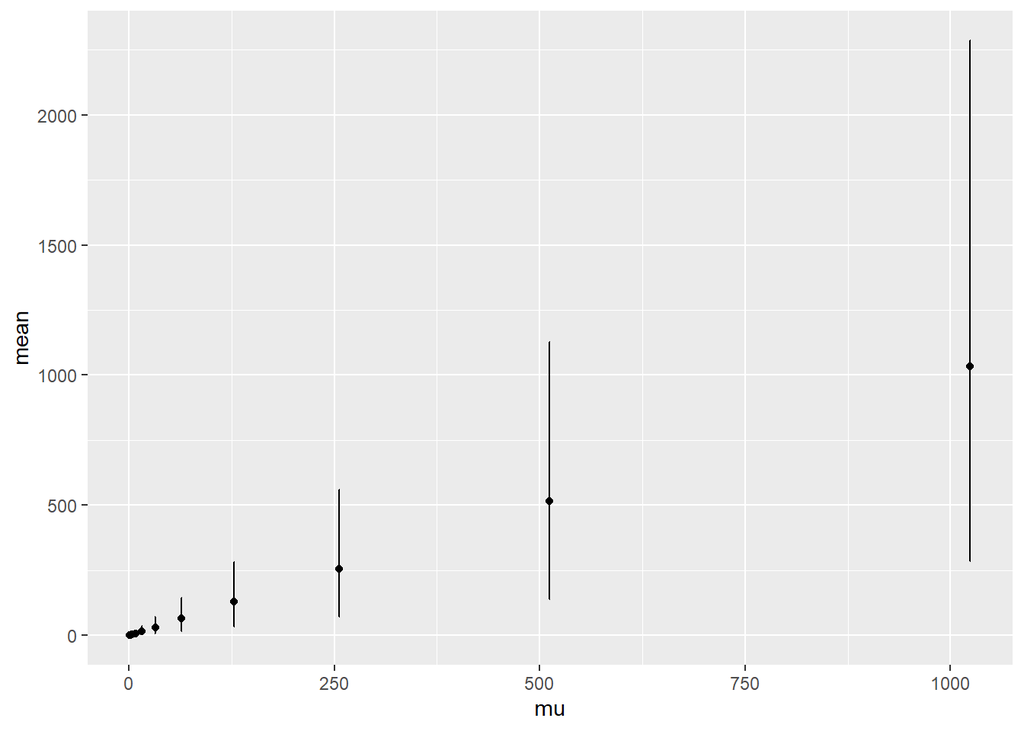

```r
#and plot the 95% confidence intervals around the mean
ggplot(simgp, aes(x = mu, y = mean, ymin = lower, ymax = upper)) +geom_point() + geom_errorbar()
```

How can we transform these data to normalize their standard deviation?

- Divide the values that correspond to mu[1] (and which are centered around mean[1]) by their standard deviation sd[1], the values that correspond to mu[2] (and which are centered around mean[2]) by their standard deviation sd[2], and so on, then the resulting values will have, by construction, a standard deviation (and thus variance) of 1.

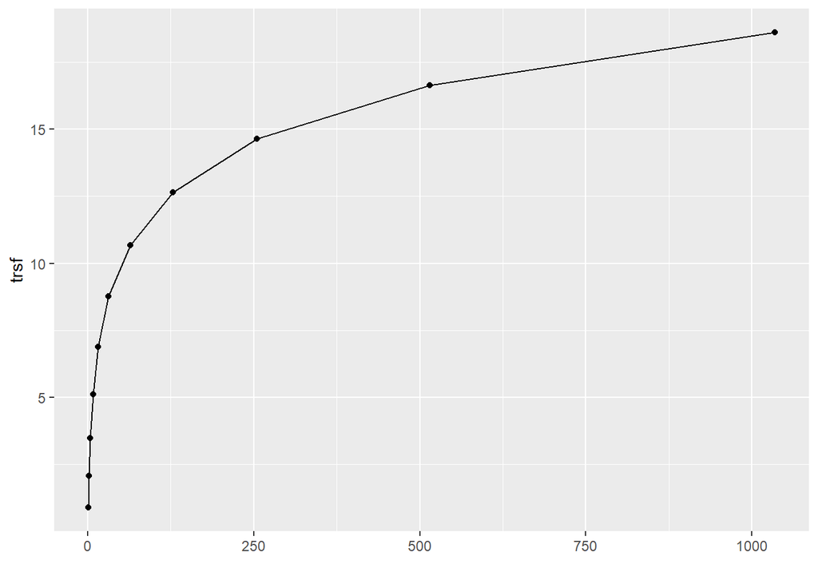

```r
simgp = mutate(simgp,
  slopes = 1 / sd,
  trsf   = cumsum(slopes * mean))
ggplot(simgp, aes(x = mean, y = trsf)) +
  geom_point() + geom_line() + xlab("")
```

**Exercises**<sup>Return</sup>